# Different approaches to quantify years of life lost from COVID-19

Tamás Ferenci

## Manuscript

Citation: Tamás Ferenci. Different approaches to quantify years of life lost from COVID-19. Eur J Epidemiol. 2021 Jun 10;1-9. DOI: 10.1007/s10654-021-00774-0. PMID: 34114188.

Published paper is available at https://link.springer.com/article/10.1007/s10654-021-00774-0.

## Analysis

We first do some preparation:

```r
library(ggplot2)
theme_set(theme_bw())
library(data.table)

name_cols <- c("atr_fib", "cancer", "copd", "demen", "diab", "h_fail", "hypert", "ihd", "renal", "liver",
               "stroke")
name_cols_age <- c("atr_fib:age", "cancer:age", "copd:age", "demen:age", "diab:age", "h_fail:age",
                   "hypert:age", "ihd:age", "renal:age", "liver:age", "stroke:age")

Pop50plus <- 3828819
```

We download the life table:

```r
if(!file.exists("LifeTableHUN.rds")) {
  LifeTableMale <- HMDHFDplus::readHMDweb("HUN", "mltper_1x1")
  LifeTableFemale <- HMDHFDplus::readHMDweb("HUN", "fltper_1x1")
  LifeTable <- rbind(cbind(Sex = "Male", LifeTableMale), cbind(Sex = "Female", LifeTableFemale))
  LifeTable <- data.table(LifeTable[LifeTable$Year==2017, ])
  saveRDS(LifeTable, "LifeTableHUN.rds")
} else LifeTable <- readRDS("LifeTableHUN.rds")
```

Next, we download the epidemiologic data:

```r
if(!file.exists("EpiData.rds")) {
  EpiData <- fread("https://covid.ourworldindata.org/data/owid-covid-data.csv")
  EpiData$date <- EpiData$date-1
} else EpiData <- readRDS("EpiData.rds")
```

We then scrape the mortality data:

```r
if(!file.exists("MortData.rds")) {
  pg <- xml2::read_html("https://koronavirus.gov.hu/elhunytak")
  lastpg <- strsplit(rvest::html_attr(rvest::html_node(pg, xpath = "//li[@class='pager-last']/a"),
                                      "href"), "=")[[1]][2]
  MortData <- rbindlist(lapply(0:lastpg, function(i)
    rvest::html_table(xml2::read_html(paste0("https://koronavirus.gov.hu/elhunytak?page=", i)))[[1]]))
  names(MortData) <- c("ID", "Sex", "Age", "Comorbidities")
  unique(MortData$Sex)
  MortData$Sex <- as.factor(ifelse(MortData$Sex%in%c("férfi", "Férfi"), "Male", "Female"))
  NewDeathsHUN <- EpiData[iso_code=="HUN", .(date, new_deaths)][!is.na(new_deaths)]
  DeathDates <- rep(NewDeathsHUN$date, NewDeathsHUN$new_deaths)
  MortData <- MortData[order(ID)][1:length(DeathDates)]
  MortData$Date <- DeathDates
  saveRDS(MortData, "MortData.rds")
} else MortData <- readRDS("MortData.rds")

StartDate <- min(MortData$Date)
EndDate <- max(MortData$Date)
```

For reproducibility of the EJE paper, we can use the original data (`MortData <- readRDS("MortData_20210512.rds")`).

Basic data:

```r
nrow(MortData)
```

```
## [1] 42069
```

```r
MortData <- MortData[Age>=50]
table(MortData$Sex)
```

```
##
## Female   Male
##  19981  20142
```

```r
nrow(MortData)
```

```
## [1] 40123
```

We create the first plot and save it:

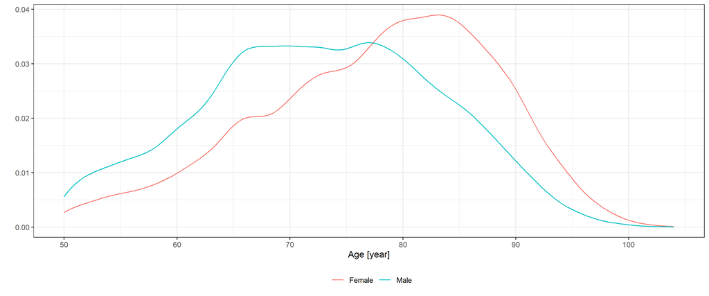

```r
ggplot(MortData, aes(x = Age, color = Sex)) + stat_density(geom = "line", position = "identity") +
  labs(x = "Age [year]", y = "") +
  theme(legend.position = "bottom", legend.title = element_blank())
```

```r
ggsave("Fig1.eps", width = 84, height = 84, units = "mm", device = cairo_ps)
```

We can now merge the life table and the mortality data:

```r
MortData <- merge(MortData, LifeTable)
MortData$Sex <- as.factor(MortData$Sex)
```

YLL using the ordinary calculation:

```r
sum(MortData$ex) # YLL
```

```
## [1] 428823
```

```r
tapply(MortData$ex, MortData$Sex, sum)
```

```
## Female   Male
## 209243 219581
```

```r
sum(MortData$ex) / nrow(MortData) # YLL per death
```

```
## [1] 10.7
```

```r
tapply(MortData$ex, MortData$Sex, mean)
```

```
## Female   Male
##   10.5   10.9
```

```r
sum(MortData$ex) / (as.numeric(difftime(EndDate, StartDate, units = "days"))/365.24 * Pop50plus) # YLL per person-year
```

```
## [1] 0.0589
```

### Original EJE paper

We then extract the comorbidities:

```r
sort(unique(do.call(c, sapply(MortData$Comorbidities, strsplit, split = ""))))
MortData$Comorbidities[grep("\u0096", MortData$Comorbidities)] <- gsub("\u0096", "", MortData$Comorbidities[grep("\u0096", MortData$Comorbidities)])

MortData$Comorbidities <- stringi::stri_trans_general(MortData$Comorbidities, "Latin-ASCII")

sort(unique(do.call(c, sapply(MortData$Comorbidities, strsplit, split = ""))))
```

```
##  [1] "-"  " "  "\t"  "\n" "\r" "\"" "("  ")"  ","  "."  "/"  ":"  ";"  "?"  "0"
## [16] "1"  "2"  "3"  "5"  "9"  "a"  "A"  "b"  "B"  "c"  "C"  "d"  "D"  "e"  "E"
## [31] "f"  "F"  "g"  "G"  "h"  "H"  "i"  "I"  "j"  "J"  "k"  "K"  "l"  "L"  "m"
## [46] "M"  "n"  "N"  "o"  "O"  "p"  "P"  "r"  "R"  "s"  "S"  "t"  "T"  "u"  "U"
## [61] "v"  "V"  "w"  "W"  "x"  "y"  "Y"  "z"  "Z"
```

```r
MortData$atr_fib <- grepl("fibril", MortData$Comorbidities, ignore.case = TRUE)
MortData$cancer <- grepl("rak|tumor|noma|daganat|metas[z]?t|attet", MortData$Comorbidities, ignore.case = TRUE)
MortData$copd <- grepl("obstru[c|k]tiv[[:blank:]]tudo|copd", MortData$Comorbidities, ignore.case = TRUE)
MortData$demen <- grepl("demen", MortData$Comorbidities, ignore.case = TRUE)
MortData$diab <- grepl("diabetes|cukorbeteg|mellitus", MortData$Comorbidities, ignore.case = TRUE)|grepl("DM|IDDM|T1DM|T2DM", MortData$Comorbidities, ignore.case = FALSE)
MortData$h_fail <- grepl("szivelegtelen", MortData$Comorbidities, ignore.case = TRUE)
MortData$hypert <- grepl("h[i|y]pertonia|magas[[:blank:]|-]?vernyomas", MortData$Comorbidities, ignore.case = TRUE)
MortData$ihd <- grepl("isch[a]?emias[[:blank:]]sziv|iszk[a]?emias[[:blank:]]sziv|angina|infar[k|c]tus", MortData$Comorbidities, ignore.case = TRUE)|grepl("IHD|CAD|CHD|AMI", MortData$Comorbidities, ignore.case = FALSE)
MortData$renal <- grepl("kronikus[[:blank:]]vese[[:blank:]|-]?elegtelen|chronicus[[:blank:]]vese[[:blank:]|-]?elegtelen", MortData$Comorbidities, ignore.case = TRUE)
MortData$liver <- grepl("kronikus[[:blank:]]maj|chronicus[[:blank:]]maj|majzsugor|majelegtelen|cirr|kronikus[[:blank:]]hepa|chronicus[[:blank:]]hepa|majmegna|alkoholos[[:blank:]]maj", MortData$Comorbidities, ignore.case = TRUE)
MortData$stroke <- grepl("stroke|sztrok|agyi[[:blank:]]erkat|agyverzes", MortData$Comorbidities, ignore.case = TRUE)

ComorbLabels <- data.table(variable = c("atr_fib", "cancer", "copd", "demen", "diab",
                                        "h_fail", "hypert", "ihd", "renal", "liver", "stroke"),
                           varlabel = c("Atrial fibrillation", "Cancer", "COPD", "Dementia", "Diabetes", "Heart failure",
                                        "Hypertension", "IHD", "Chronic renal failure", "Chronic liver disease", "Stroke"))
```

We calculate the first table and save it:

```r
tab1 <- merge(melt(MortData,  measure.vars = ComorbLabels$variable), ComorbLabels)[
  ,.(mean(value)*100, binom.test(sum(value), length(value))$conf.int[1]*100,
     binom.test(sum(value), length(value))$conf.int[2]*100), .(varlabel)
][, .(varlabel, paste0(round(V1, 1), " (", round(V2, 1), "-", round(V3, 1), ")"))]
knitr::kable(tab1)
```

| varlabel | V2 |
| --- | --- |
| Atrial fibrillation | 3.5 (3.4-3.7) |
| Cancer | 11.1 (10.8-11.4) |
| COPD | 4.2 (4-4.4) |
| Dementia | 6.9 (6.7-7.2) |
| Diabetes | 29.5 (29-29.9) |
| Heart failure | 7 (6.7-7.2) |
| Hypertension | 67.1 (66.6-67.5) |
| IHD | 14.2 (13.9-14.6) |
| Chronic liver disease | 0.8 (0.7-0.9) |
| Chronic renal failure | 5.1 (4.9-5.3) |
| Stroke | 2.9 (2.8-3.1) |

```r
write.csv2(tab1, "Tab1.csv")
```

We then create the second figure and save it:

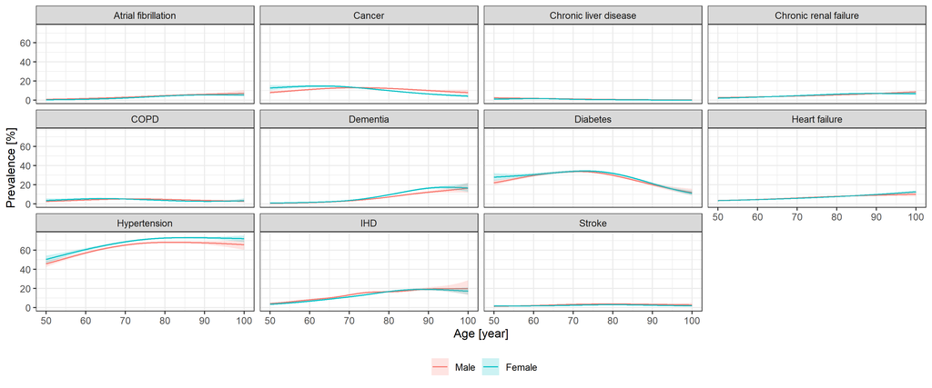

```r
predgrid <- expand.grid(Age = seq(50, 100, 0.1), Sex = c("Male", "Female"))
ComorbPrevs <- rbindlist(setNames(lapply(ComorbLabels$variable, function(v) {
  fit <- mgcv::gam(as.formula(paste0(v, "~ s(Age, by = Sex) + Sex")), data = MortData,
                   family = binomial)
  cbind(predgrid, with(predict(fit, predgrid, se.fit = TRUE),
                       data.frame(est = plogis(fit), lwr = plogis(fit - 1.96*se.fit),
                                  upr = plogis(fit + 1.96*se.fit))))
}), ComorbLabels$varlabel), idcol = TRUE)
ggplot(ComorbPrevs,
       aes(x = Age, y = est*100, color = Sex, fill = Sex, ymin = lwr*100, ymax = upr*100)) +
  geom_line() + geom_ribbon(alpha = 0.2, linetype = 0) + facet_wrap(~.id) +
  labs(x = "Age [year]", y = "Prevalence [%]") +
  theme(legend.position = "bottom", legend.title = element_blank())
```

```r
ggsave("Fig2.eps", width = 174, height = 174, units = "mm", device = cairo_ps)
```

And then the third one:

```r
MortData$ComorbCount <- rowSums(MortData[, ..name_cols])
prop.table(table(MortData$ComorbCount))*100
```

```
##
##        0        1        2        3        4        5        6        7
## 15.04873 36.45540 33.20290 12.30716  2.53221  0.39130  0.05982  0.00249
```

```r
mean(MortData$ComorbCount>2)*100
```

```
## [1] 15.3
```

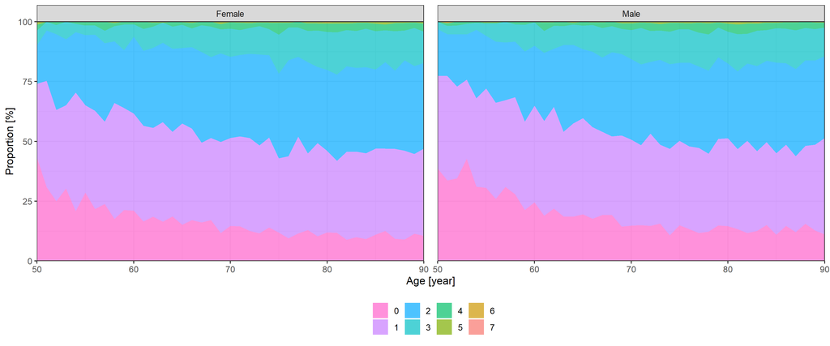

```r
ggplot(reshape2::melt(table(MortData$ComorbCount, MortData$Age, MortData$Sex)),
       aes(x = Var2, fill = forcats::fct_rev(as.factor(Var1)), y = value)) +
  geom_area(position = "fill", alpha = 0.7) +
  facet_grid(cols = vars(Var3)) + scale_x_continuous(expand = c(0, 0), limits = c(50, 90)) +
  scale_y_continuous(labels = scales::percent_format(suffix = ""), expand = c(0, 0)) +
  labs(x = "Age [year]", y = "Proportion [%]", fill = "Number of comorbidities") +
  guides(fill = guide_legend(reverse = TRUE)) +
  theme(legend.position = "bottom", legend.title = element_blank(),
        panel.spacing = unit(1, "lines"))
```

```r
ggsave("Fig3.eps", width = 174, height = 174, units = "mm", device = cairo_ps)
```

Next, we integrate the external survival model and run a few checks:

```r
male_coef <- read.csv("https://raw.githubusercontent.com/dmcalli2/covid19_yll_final/master/Data/sail_outputs/male_coef.csv")
male_coef <- setNames(male_coef$x, male_coef$X)
female_coef <- read.csv("https://raw.githubusercontent.com/dmcalli2/covid19_yll_final/master/Data/sail_outputs/female_coef.csv")
female_coef <- setNames(female_coef$x, female_coef$X)

SurvGomp <- function(t, start, ...) {
  ret <- (1 - flexsurv:::pgompertz_work(t, ...))/(1-flexsurv:::pgompertz_work(start, ...))
  ret[t<start] <- 1
  ret
}

times_vect <- seq(50, 150, 0.1)

temp <- 1-SurvGomp(t = times_vect, start = MortData$Age[2], shape = male_coef["shape"],
                   rate = exp(male_coef["rate"] +
                                as.matrix(MortData[2, ..name_cols])%*%male_coef[name_cols] +
                                (MortData$Age[2]*as.matrix(MortData[2, ..name_cols]))%*%male_coef[name_cols_age]),
                   lower_tail = TRUE, give_log = FALSE)

temp <- 1-SurvGomp(t = times_vect, start = 60, shape = female_coef["shape"],
                   rate = exp(female_coef["rate"]),
                   lower_tail = TRUE, give_log = FALSE)

sum(temp - c(0, temp[-length(temp)]))
```

```
## [1] 1
```

```r
sum((temp - c(0, temp[-length(temp)]))*times_vect)
```

```
## [1] 88
```

```r
sum((temp - c(0, temp[-length(temp)]))*times_vect)-MortData$Age[2]
```

```
## [1] 38
```

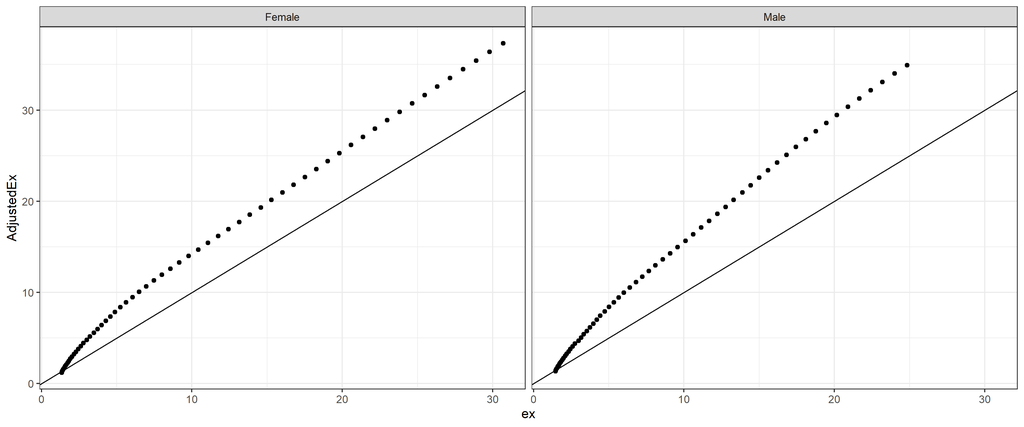

```r
offsetgrid <- data.table(expand.grid(Sex = c("Male", "Female"), Age = 50:110))
offsetgrid$AdjustedEx <- sapply(1:nrow(offsetgrid), function(i) {
  usedcoefs <- if(offsetgrid$Sex[i]=="Male") male_coef else female_coef
  temp <- 1-SurvGomp(t = times_vect, start = offsetgrid$Age[i], shape = usedcoefs["shape"],
                     rate = exp(usedcoefs["rate"]), lower_tail = TRUE, give_log = FALSE)
  sum((temp - c(0, temp[-length(temp)]))*times_vect)-offsetgrid$Age[i]
})
offsetgrid <- merge(offsetgrid, LifeTable)
ggplot(offsetgrid, aes(x = ex, y = AdjustedEx)) + geom_point() + facet_grid(cols = vars(Sex)) +
  geom_abline(intercept = 0, slope = 1)
```

```r
offsetgrid$ratio <- offsetgrid$ex/offsetgrid$AdjustedEx
offsetgrid$leratio <- (offsetgrid$Age + offsetgrid$ex)/(offsetgrid$Age + offsetgrid$AdjustedEx)

MortData$AdjustedEx <- sapply(1:nrow(MortData), function(i) {
  usedcoefs <- if(MortData$Sex[i]=="Male") male_coef else female_coef
  temp <- 1-SurvGomp(t = times_vect, start = MortData$Age[i], shape = usedcoefs["shape"],
                     rate = exp(usedcoefs["rate"] +
                                  as.matrix(MortData[i, ..name_cols])%*%usedcoefs[name_cols] +
                                  (MortData$Age[i]*as.matrix(MortData[i, ..name_cols]))%*%usedcoefs[name_cols_age]),
                     lower_tail = TRUE, give_log = FALSE)
  # sum((temp - c(0, temp[-length(temp)]))*times_vect)*offsetgrid[Sex==MortData$Sex[i]&Age==MortData$Age[i]]$leratio-MortData$Age[i]
  (sum((temp - c(0, temp[-length(temp)]))*times_vect)-MortData$Age[i])*offsetgrid[Sex==MortData$Sex[i]&Age==MortData$Age[i]]$ratio
})
```

We can now create the fourth figure:

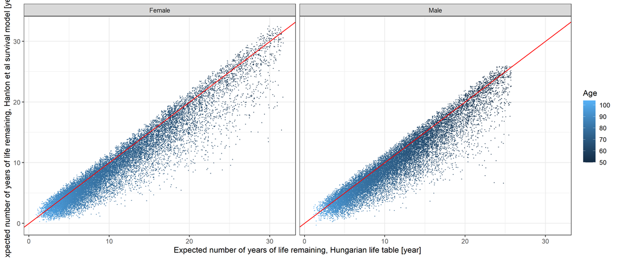

```r
ggplot(MortData, aes(x = ex, y = AdjustedEx, color = Age)) +
  geom_jitter(size = 0.1, width = 1, height = 1) +
  facet_grid(cols = vars(Sex)) + geom_abline(intercept = 0, slope = 1, color = "red") +
  labs(x = "Expected number of years of life remaining, Hungarian life table [year]",
       y = "Expected number of years of life remaining, Hanlon et al survival model [year]")
```

```r
ggsave("Fig4.eps", width = 174, height = 174, units = "mm", device = cairo_ps)
```

And calculate the adjusted YLLs:

```r
sum(MortData$AdjustedEx) # YLL
```

```
## [1] 375614
```

```r
sum(MortData$AdjustedEx) / nrow(MortData) # YLL per death
```

```
## [1] 9.36
```

```r
tapply(MortData$AdjustedEx, MortData$Sex, mean)
```

```
## Female   Male
##   9.13   9.59
```

```r
sum(MortData$AdjustedEx) / (as.numeric(difftime(EndDate, StartDate, units = "days"))/365.24 * Pop50plus) # YLL per person-year
```

```
## [1] 0.0516
```

```r
100-sum(MortData$AdjustedEx)/sum(MortData$ex)*100
```

```
## [1] 12.4
```

Life-table norms:

```r
sum(LifeTable[Sex=="Female", .(dx*ex)]$V1)/sum(LifeTable[Sex=="Female"]$dx)
```

```
## [1] 10.3
```

```r
sum(LifeTable[Sex=="Male", .(dx*ex)]$V1)/sum(LifeTable[Sex=="Male"]$dx)
```

```
## [1] 11.9
```

```r
sum(LifeTable[, .(dx*ex)]$V1)/sum(LifeTable$dx)
```

```
## [1] 11.1
```

### Reply letter

We first download the GBD Reference Life Table and transform it to the forms that we will later need:

```r
GBDRef5 <- fread("IHME_GBD_2019_TMRLT_Y2021M01D05.CSV", check.names = TRUE)
GBDRef5100 <- rbind(GBDRef5, data.table(Age = 100,
                                        Life.Expectancy = GBDRef5[Age==95]$Life.Expectancy))
GBDRef <- data.table(Age = 0:95, ex = approx(GBDRef5$Age, GBDRef5$Life.Expectancy, 0:95)$y)
GBDRef <- rbind(GBDRef, data.table(Age = 96:105, ex = GBDRef[Age==95]$ex))

MortData <- merge(MortData, GBDRef[, .(Age, GBDex = ex)], by = "Age")
```

We can now calculate the aspirational metrics:

```r
sum(MortData$GBDex)
```

```
## [1] 718170
```

```r
sum(MortData$GBDex)/nrow(MortData)
```

```
## [1] 17.9
```

```r
sapply(c(70, 75, 80, 85), function(targ) sum(pmax(targ-MortData$Age, 0)))
```

```
## [1]  95118 174580 285677 430825
```

```r
sapply(c(70, 75, 80, 85), function(targ) sum(pmax(targ-MortData$Age, 0)))/nrow(MortData)
```

```
## [1]  2.37  4.35  7.12 10.74
```

Investigating how the result of the fixed target age approach depends on the target age set:

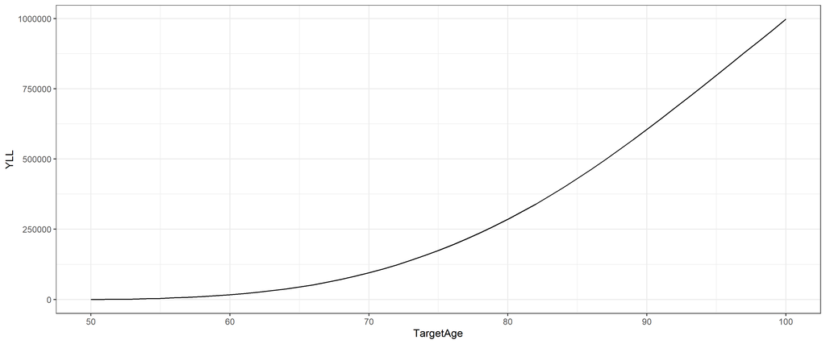

```r
yllaspfixed <- data.table(TargetAge = 50:100,
                          YLL = sapply(50:100, function(targ) sum(pmax(targ-MortData$Age, 0))))
ggplot(yllaspfixed, aes(x = TargetAge, y = YLL)) + geom_line()
```

```r
summary(lm(YLL/1e5 ~ poly(TargetAge, 2, raw = TRUE), data = yllaspfixed))
```

```
##
## Call:
## lm(formula = YLL/100000 ~ poly(TargetAge, 2, raw = TRUE), data = yllaspfixed)
##
## Residuals:
##      Min       1Q   Median       3Q      Max
## -0.21419 -0.06513  0.00273  0.06983  0.11386
##
## Coefficients:
##                                   Estimate Std. Error t value
## (Intercept)                     17.0102752  0.3205817    53.1
## poly(TargetAge, 2, raw = TRUE)1 -0.6027649  0.0087750   -68.7
## poly(TargetAge, 2, raw = TRUE)2  0.0053369  0.0000583    91.6
##                                            Pr(>|t|)
## (Intercept)                     <0.0000000000000002 ***
## poly(TargetAge, 2, raw = TRUE)1 <0.0000000000000002 ***
## poly(TargetAge, 2, raw = TRUE)2 <0.0000000000000002 ***
## ---
## Signif. codes:  0 '***' 0.001 '**' 0.01 '*' 0.05 '.' 0.1 ' ' 1
##
## Residual standard error: 0.0806 on 48 degrees of freedom
## Multiple R-squared:  0.999,  Adjusted R-squared:  0.999
## F-statistic: 3.75e+04 on 2 and 48 DF,  p-value: <0.0000000000000002
```

For the international analysis, we first download and prepare the COVerAGE-DB dataset (at 5 year age resolution):

```r
osfr::osf_download(osfr::osf_retrieve_file("7tnfh"), conflicts = "overwrite")
```

```
## # A tibble: 1 x 4
##   name         id                       local_path     meta
##   <chr>        <chr>                    <chr>          <list>
## 1 Output_5.zip 5f3ed65ff579150074ea6df0 ./Output_5.zip <named list [3]>
```

```r
CADB5 <- as.data.table(readr::read_csv("Output_5.zip", skip = 3, col_types = "ccccciiddd"))
CADB5$Date <- as.Date(CADB5$Date, format = "%d.%m.%Y")

CADB5 <- merge(CADB5, CADB5[,.(maxdate = max(Date[!is.na(Deaths)])),
                            .(Country, Region)][maxdate>=as.Date("2021-12-01")])
CADB5 <- CADB5[Date==maxdate][Sex=="b"]

CADB5 <- merge(CADB5, GBDRef5100, by = "Age")
```

We can alread calculate the aspirational YLLs:

```r
CADB5[, .(YLLperDeath = sum(Deaths*Life.Expectancy)/sum(Deaths)),
      .(Country, Region)][!is.na(YLLperDeath)][order(YLLperDeath)]
```

```
##         Country    Region YLLperDeath
##   1:      Spain      Lugo        12.0
##   2:      Spain   Ourense        12.1
##   3:    Belgium  Flanders        12.2
##   4:      Spain     Soria        12.5
##   5:      Spain   Segovia        12.8
##  ---
## 287:   Colombia   Guainia        32.2
## 288:   Paraguay Canindeyu        33.5
## 289:  Indonesia       All        34.0
## 290:       Togo       All        34.6
## 291: Bangladesh       All        36.2
```

```r
CADB5[, .(YLLperDeath = sum(pmax(70-Age, 0)*Deaths)/sum(Deaths)),
      .(Country, Region)][!is.na(YLLperDeath)][order(YLLperDeath)]
```

```
##         Country    Region YLLperDeath
##   1:      Spain   Ourense       0.741
##   2:      Spain      Lugo       0.873
##   3:      Spain    Burgos       1.058
##   4:      Spain      Leon       1.066
##   5:      Spain     Soria       1.077
##  ---
## 287:   Colombia   Guainia      13.286
## 288:   Paraguay Canindeyu      14.861
## 289:  Indonesia       All      14.989
## 290:       Togo       All      15.839
## 291: Bangladesh       All      17.406
```

But to calculate the standard life table YLL (using each country’s own life table), we need to download the national life tables and merge it with our dataset:

```r
unique(CADB5[Region=="All"]$Country)
```

```
##  [1] "Afghanistan"      "Argentina"        "Australia"        "Austria"
##  [5] "Bangladesh"       "Belgium"          "Chile"            "Colombia"
##  [9] "Denmark"          "Finland"          "France"           "Germany"
## [13] "Hungary"          "Indonesia"        "Italy"            "Jamaica"
## [17] "Jordan"           "Latvia"           "Moldova"          "Netherlands"
## [21] "New Zealand"      "Northern Ireland" "Norway"           "Paraguay"
## [25] "Peru"             "Philippines"      "Scotland"         "Slovakia"
## [29] "Somalia"          "South Korea"      "Spain"            "Sweden"
## [33] "Switzerland"      "Togo"             "USA"
```

```r
countries <- data.table(
  Country = c("Australia", "Austria", "Belgium", "Bulgaria", "Chile", "Croatia",
              "Denmark", "Estonia", "Finland", "France", "Germany", "Hungary",
              "Italy", "Japan", "Latvia" ,"Netherlands", "New Zealand",
              "Northern Ireland", "Norway", "Scotland", "Slovakia",
              "Spain", "Sweden", "Switzerland", "USA"),
  Code = c("AUS", "AUT", "BEL", "BGR", "CHL", "HRV", "DNK", "EST", "FIN", "FRATNP",
           "DEUTNP", "HUN", "ITA", "JPN", "LVA", "NLD", "NZL_NP", "GBR_NIR", "NOR",
           "GBR_SCO", "SVK", "ESP", "SWE", "CHE", "USA"))

if(!file.exists("LifeTableWord.rds")) {
  LifeTableWorld <- rbindlist(lapply(countries$Code, function(cod)
    data.table(Code = cod, HMDHFDplus::readHMDweb(cod, "bltper_5x1"))))
  saveRDS(LifeTableWorld, "LifeTableWord.rds")
} else LifeTableWorld <- readRDS("LifeTableWord.rds")

LifeTableWorld <- merge(LifeTableWorld, LifeTableWorld[,.(maxyear = max(Year)),.(Code)][maxyear>=2017])
LifeTableWorld <- LifeTableWorld[Year==maxyear]
LifeTableWorld <- merge(LifeTableWorld, countries, by = "Code")
```

We can now calculate the YLL with every approach:

```r
yllworld <-
  rbind(merge(CADB5[Region=="All"], LifeTableWorld,
              by = c("Country", "Age"))[, .(Type = "Actual LT",
                                            YLLperDeath = sum(Deaths*ex)/sum(Deaths)), .(Country)],
        CADB5[Region=="All", .(Type = "GBD",YLLperDeath = sum(Deaths*Life.Expectancy)/sum(Deaths)),
              .(Country)],
        rbindlist(lapply(c(70, 75, 80, 85), function(targ)
          CADB5[Region=="All", .(Type = paste0("Fixed, target: ", targ),
                                 YLLperDeath = sum(pmax(targ-Age, 0)*Deaths)/sum(Deaths)),
                .(Country)])))
```

And we can plot the results:

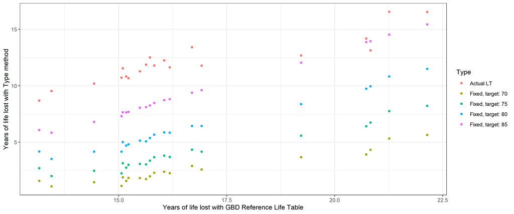

```r
ggplot(melt(dcast(yllworld, Country ~ Type, value.var = "YLLperDeath")[!is.na(`Actual LT`)],
            id.vars = c("Country", "GBD")),
       aes(x = GBD, y = value, group = variable, color = variable)) + geom_point() +
  labs(color = "Type", y = "Years of life lost with Type method",
       x = "Years of life lost with GBD Reference Life Table")
```

```r
ggsave("ReplyFig1.eps", width = 174, height = 174, units = "mm", device = cairo_ps)
```

Just out of curiosity, we can check how the YLL with the fixed target age approach depends on the target age, internationally:

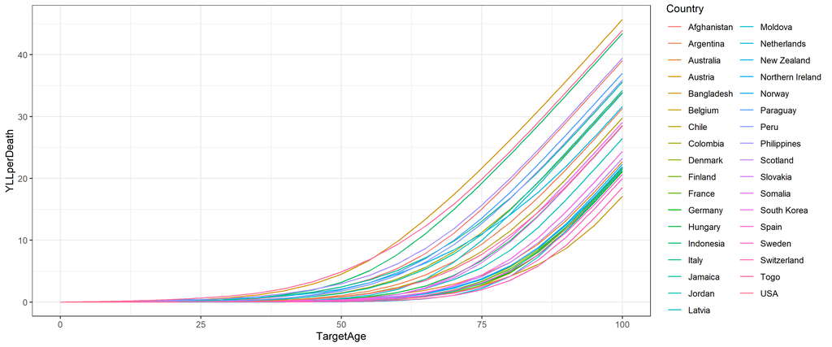

```r
ggplot(CADB5[Region=="All", .(TargetAge = 0:100,
                              YLLperDeath = sapply(0:100, function(targ)
                                sum(pmax(targ-Age, 0)*Deaths)/sum(Deaths))),
             .(Country)], aes(x = TargetAge, y = YLLperDeath, group = Country, color = Country)) +
  geom_line()
```

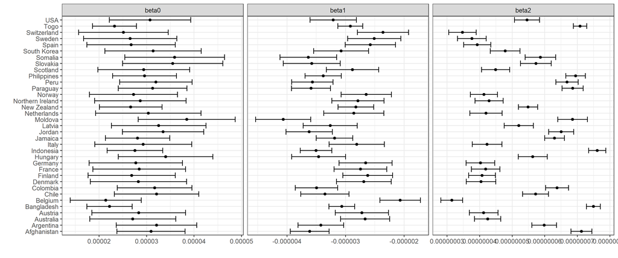

```r
fitdata <- CADB5[Region=="All", .(TargetAge = 0:100,
                                  YLLperDeath = sapply(0:100, function(targ)
                                    sum(pmax(targ-Age, 0)*Deaths)/sum(Deaths))),
                 .(Country)]
fitres <- lapply(unique(fitdata$Country), function(country)
  lm(YLLperDeath/1e5 ~ poly(TargetAge, 2, raw = TRUE), data = fitdata[Country==country]))

fitres <- rbindlist(lapply(1:length(fitres),
                           function(i) data.table(unique(fitdata$Country)[i],
                                                  c("beta0", "beta1", "beta2"),
                                                  coef(fitres[[i]]), confint(fitres[[i]]))))
colnames(fitres) <- c("Country", "Coefficient", "Estimate", "CIlwr", "CIupr")

ggplot(fitres, aes(x = Estimate, xmin = CIlwr, xmax = CIupr, y = Country)) + geom_point() +
  geom_errorbar() + facet_grid(cols = vars(Coefficient), scales = "free") +
  labs(x = "", y = "")
```

Finally, we create the other plot:

```
## Warning: Removed 12 row(s) containing missing values (geom_path).
```

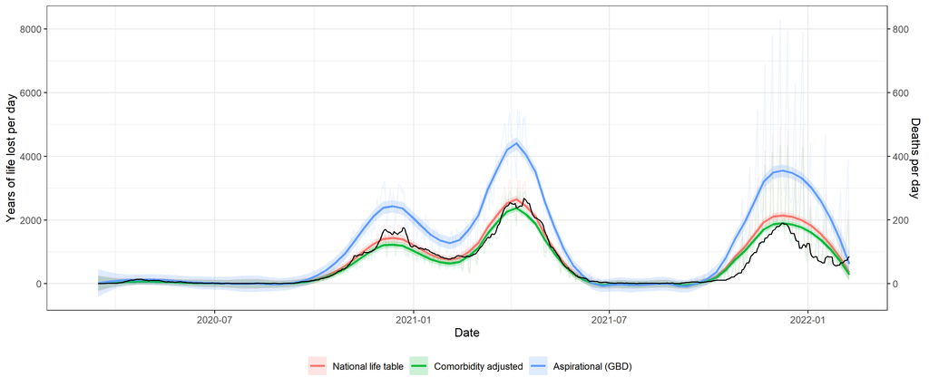

```r
ggplot(melt(MortData[, .(`National life table` = sum(ex),
                         `Comorbidity adjusted` = sum(AdjustedEx),
                         `Aspirational (GBD)` = sum(GBDex)), .(Date)][order(Date)],
            id.vars = "Date"),
       aes(x = Date, y = value, group = variable, color = variable, fill = variable)) +
  geom_line(alpha = 0.1) + geom_smooth(span = 0.2, alpha = 0.2) +
  geom_line(data = EpiData[location=="Hungary"],
            aes(x = date, y = new_deaths_smoothed*10), inherit.aes = FALSE) +
  scale_y_continuous("Years of life lost per day",
                     sec.axis = sec_axis(~ ./10, name = "Deaths per day")) +
  labs(color = "", fill = "") + theme(legend.position = "bottom")
```

```r
ggsave("ReplyFig2.eps", width = 174, height = 174, units = "mm", device = cairo_ps)
```

```
## Warning: Removed 12 row(s) containing missing values (geom_path).
```